# 資料探勘

曾意儒 Yi-Ju Tseng  
2017/05/22

### 對應書本章節

[10 資料探勘](http://yijutseng.github.io/DataScienceRBook/datamining.html)

## 大綱

- 什麼是資料探勘
- Regression 迴歸
- Decision Trees 決策樹

### 什麼是資料探勘

建立從**輸入資料**學習新資訊，變成智慧的**演算法**或**資料模式**，用來**預測事件**或**協助決策**

- 用人工智慧、機器學習、統計學等方法
- 在相對較大型的資料集中發現模式的計算過程
- 當資料太`少`或`太髒`的時候，資料探勘的效力會被影響。

### 資料探勘條件

資料探勘要派上用場，必須有以下條件：

- 有一些模式/模型可`學`
- 很難定義這些模式/模型
- 有資料可`學`這些模式/模型

### 資料探勘可應用在

- 天氣預測
- 搜尋建議、購物建議
- 股市預測
- 臉部辨識、指紋辨識
- 垃圾郵件標記
- 尿布啤酒

### 資料探勘的分類

- **監督式**學習與**非監督式**學習
- 監督式學習的特點是訓練資料中有**正確答案**，由輸入物件和預期輸出所組成，而演算法可以由訓練資料中學到或建立一個模式，並依此模式推測新的實例
- 非監督式學習則不用提供**正確答案**，也就是不需要人力來輸入標籤，單純利用訓練資料的特性，將資料分群分組。

### 資料探勘的分類

- Supervised learning 監督式學習
  - Regression 迴歸：真實的'值'（股票、氣溫）
  - Classification 分類：分兩類（P/N, Yes/No, M/F, Sick/Not sick）/分多類 (A/B/C/D)
- Unsupervised learning 非監督式學習
  - Clustering 分群
  - Association Rules 關聯式規則

### 監督式學習

在**監督式**學習中常見的資料探勘演算法如下：

- Linear Regression 線性迴歸
- Logistic Regression 羅吉斯迴歸、邏輯迴歸
- Support Vector Machines 支持向量機
- Decision Trees 決策樹
- K-Nearest Neighbor
- Neural Networks 神經網路
- Deep Learning 深度學習

### 非監督式學習

在**非監督式**學習中常見的資料探勘演算法如下：

- Hierarchical clustering 階層式分群
- K-means clustering
- Neural Networks 神經網路
- Deep Learning 深度學習

### Regression 迴歸

- 用在了解兩個或多個變數間`是否相關`、`相關方向與強度`
- 建立`數學模型`以便觀察特定變數來預測研究者感興趣的變數

常見的迴歸分析演算法包括：

- Linear Regression 線性迴歸
- Logistic Regression 羅吉斯迴歸、邏輯迴歸

### Linear Regression 線性迴歸

- 嘗試將Linear Regression 線性迴歸用在NBA的資料
- 做NBA`得分`與`上場分鐘數`的線性迴歸觀察

```r
#讀入SportsAnalytics package
library(SportsAnalytics)
#擷取2015-2016年球季球員資料
NBA1516<-fetch_NBAPlayerStatistics("15-16")
```

### 迴歸線作圖

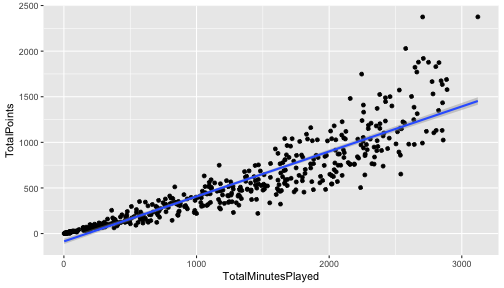

```r
library(ggplot2)
ggplot(NBA1516,
       aes(x=TotalMinutesPlayed,
           y=TotalPoints))+
  geom_point()+
  geom_smooth(method = "glm")
```

### lm()

- 在R中，最基本的簡單線性迴歸分析為`lm()`
- `lm(formula,data=資料名稱)`，搭配formula使用
- formula的撰寫方法為：依變項~自變項1＋自變項2＋….

```r
lm(TotalPoints~TotalMinutesPlayed,
   data =NBA1516)
```

```
Call:
lm(formula = TotalPoints ~ TotalMinutesPlayed, data = NBA1516)

Coefficients:
       (Intercept)  TotalMinutesPlayed
          -85.9071              0.4931
```

TotalPoints = `0.4931` * TotalMinutesPlayed `-85.9071`

### glm()

- 更被廣泛使用的是廣義線性迴歸模型generalized linear models (glm)，`glm()`
- 使用方法與`lm()`類似
- 包括線性迴歸模型和邏輯迴歸模型
- 如果需要修改預設模型，可設定family參數：
  - `family="gaussian"` 線性模型模型
  - `family="binomial"` 邏輯迴歸模型
  - `family="poisson"` 卜瓦松迴歸模型

### Gaussian distribution

Gaussian distribution高斯函數是`常態分布`的密度函數

[figure not shown]

### Binomial distribution

Binomial distribution二項分布是`n個獨立的是/非試驗中成功的次數`的離散機率分布

[figure not shown]

### Poisson distribution

Poisson distribution`次數`分佈：

- 某一服務設施在一定時間內受到的服務請求的次數
- 公車站的候客人數
- 自然災害發生的次數

[figure not shown]

### 廣義線性迴歸與NBA

分析`得分`與`上場分鐘數`和`兩分球出手數`的關係範例

```r
# e+01: 10^1 / e-04: 10^(-4)
glm(TotalPoints ~
      TotalMinutesPlayed+FieldGoalsAttempted,
    data =NBA1516)
```

```
Call:  glm(formula = TotalPoints ~ TotalMinutesPlayed + FieldGoalsAttempted,
    data = NBA1516)

Coefficients:
        (Intercept)   TotalMinutesPlayed  FieldGoalsAttempted
         -1.799e+01           -2.347e-04            1.256e+00

Degrees of Freedom: 475 Total (i.e. Null);  473 Residual
Null Deviance:      99360000
Residual Deviance: 2160000  AIC: 5367
```

### 廣義線性迴歸與NBA

```
Call:  glm(formula = TotalPoints ~ TotalMinutesPlayed + FieldGoalsAttempted,
    data = NBA1516)

Coefficients:
        (Intercept)   TotalMinutesPlayed  FieldGoalsAttempted
         -1.799e+01           -2.347e-04            1.256e+00

Degrees of Freedom: 475 Total (i.e. Null);  473 Residual
Null Deviance:      99360000
Residual Deviance: 2160000  AIC: 5367
```

TotalPoints = `-0.0002347` * TotalMinutesPlayed + `1.255794` *FieldGoalsAttempted `-17.99`

### 廣義線性迴歸與NBA

如需使用多變量線性迴歸來分析`得分`與`上場分鐘數`和`兩分球出手數`和`守備位置`的關係，可修改formula

```r
glm(TotalPoints~
      TotalMinutesPlayed+FieldGoalsAttempted+Position,
    data =NBA1516)
```

```
Call:  glm(formula = TotalPoints ~ TotalMinutesPlayed + FieldGoalsAttempted +
    Position, data = NBA1516)

Coefficients:
        (Intercept)   TotalMinutesPlayed  FieldGoalsAttempted
          22.852223            -0.006537             1.275721
         PositionPF           PositionPG           PositionSF
         -39.416327           -65.034646           -38.522299
         PositionSG
         -52.175144

Degrees of Freedom: 474 Total (i.e. Null);  468 Residual
  (1 observation deleted due to missingness)
Null Deviance:      99080000
Residual Deviance: 1975000  AIC: 5322
```

```r
# e+01: 10^1 / e-04: 10^(-4)
```

### 廣義線性迴歸與NBA

```
Call:  glm(formula = TotalPoints ~ TotalMinutesPlayed + FieldGoalsAttempted +
    Position, data = NBA1516)

Coefficients:
        (Intercept)   TotalMinutesPlayed  FieldGoalsAttempted
          22.852223            -0.006537             1.275721
         PositionPF           PositionPG           PositionSF
         -39.416327           -65.034646           -38.522299
         PositionSG
         -52.175144

Degrees of Freedom: 474 Total (i.e. Null);  468 Residual
  (1 observation deleted due to missingness)
Null Deviance:      99080000
Residual Deviance: 1975000  AIC: 5322
```

### 虛擬變項 Dummy Variable

- `守備位置`的變項被轉為**虛擬變項 Dummy Variable**
- PositionPF、PositionPG、PositionSF、PositionSG
- 如果是控球後衛（PG），會得到：
  - PositionPF=0
  - PositionPG=1
  - PositionSF=0
  - PositionSG=0

### 中鋒去哪了？

- 中鋒被當作基準項
- 當守備位置是中鋒( C )時，會得到：
  - PositionPF=0
  - PositionPG=0
  - PositionSF=0
  - PositionSG=0

### 線性迴歸練習

- 用[BostonHousing](https://archive.ics.uci.edu/ml/datasets/Housing)資料
  - install.packages(“mlbench”)
  - library(mlbench)
  - data(BostonHousing)
- 使用crim、tax、dis欄位預測medv(Median value of owner-occupied homes in $1000's)
  - glm()廣義線性迴歸

### 線性迴歸總結

總結以上，多變量線性迴歸分析有下列特色：

- 假設：各變數相互獨立！
- 若自變項X是類別變項，需要建立`虛擬變項`
- 在R裡，`類別變項`請記得轉成factor，R會自動建立`虛擬變項`
- 用在`依變數為連續變數`，`自變數為連續變數或虛擬變數`的場合

### Logistic Regression 羅吉斯迴歸

常用在`依變數為二元變數（非0即1）`的場合，如：

- 生病/沒生病
- 錄取/不錄取
- `family="binomial"` 邏輯迴歸模型

### 分析為什麼錄取/不錄取？

```r
mydata <- read.csv("https://raw.githubusercontent.com/CGUIM-BigDataAnalysis/BigDataCGUIM/master/binary.csv")
```

```r
# GRE:某考試成績, GPA:在校平均成績, rank:學校聲望
head(mydata)
```

| admit | gre | gpa | rank |
| --- | --- | --- | --- |
| 0 | 380 | 3.61 | 3 |
| 1 | 660 | 3.67 | 3 |
| 1 | 800 | 4.00 | 1 |
| 1 | 640 | 3.19 | 4 |
| 0 | 520 | 2.93 | 4 |
| 1 | 760 | 3.00 | 2 |

### 分析為什麼錄取/不錄取？

```r
mydata$rank <- factor(mydata$rank)
mylogit <- glm(admit ~ gre + gpa + rank,
               data = mydata,
               family = "binomial")
sum<-summary(mylogit)
```

```r
sum$coefficients
```

|  | Estimate | Std. Error | z value | Pr(>\|z\|) |
| --- | --- | --- | --- | --- |
| (Intercept) | -3.9899791 | 1.1399509 | -3.500132 | 0.0004650 |
| gre | 0.0022644 | 0.0010940 | 2.069863 | 0.0384651 |
| gpa | 0.8040375 | 0.3318193 | 2.423119 | 0.0153879 |
| rank2 | -0.6754429 | 0.3164897 | -2.134171 | 0.0328288 |
| rank3 | -1.3402039 | 0.3453064 | -3.881202 | 0.0001039 |
| rank4 | -1.5514637 | 0.4178316 | -3.713131 | 0.0002047 |

### 羅吉斯迴歸練習

- 用[PimaIndiansDiabetes](https://archive.ics.uci.edu/ml/datasets/Pima+Indians+Diabetes)資料
  - install.packages(“mlbench”)
  - library(mlbench)
  - data(PimaIndiansDiabetes)
- 使用pregnant、glucose、triceps、mass欄位預測diabetes
  - glm()廣義線性迴歸
  - family = “binomial”

### 最佳模型篩選

到底該用哪個模型來預測，會得到最準確的結果？在迴歸模型中，常用的判斷準則包括：

- Akaike’s Information Criterion (AIC)
- Bayesian Information Criterion (BIC)

### AIC

AIC和BIC都是數值越小越好，以下建立三個模型，並比較其AIC

```r
OneVar<-glm(TotalPoints~
              TotalMinutesPlayed,
            data =NBA1516)
TwoVar<-glm(TotalPoints~
              TotalMinutesPlayed+
              FieldGoalsAttempted,
            data =NBA1516)
ThreeVar<-glm(TotalPoints~
                TotalMinutesPlayed+
                FieldGoalsAttempted+Position,
              data =NBA1516)
```

### AIC

```r
c(OneVar$aic,TwoVar$aic,ThreeVar$aic)
```

```
[1] 6338.913 5366.763 5321.972
```

### 所有參數都有用嗎？

- 在建立迴歸模型時，常會遇到的問題：到底該放多少參數？
- 所有參數都有用嗎？
- 藉由觀察coefficients來判斷參數在模型中的"實用程度“

```r
sum2<-summary(TwoVar)
sum2$coefficients
```

|  | Estimate | Std. Error | t value | Pr(>\|t\|) |
| --- | --- | --- | --- | --- |
| (Intercept) | -17.9885533 | 5.6597583 | -3.1783254 | 0.0015783 |
| TotalMinutesPlayed | -0.0002347 | 0.0094746 | -0.0247733 | 0.9802462 |
| FieldGoalsAttempted | 1.2557937 | 0.0222395 | 56.4668275 | 0.0000000 |

### 所有參數都有用嗎？

```r
sum3<-summary(ThreeVar)
sum3$coefficients
```

|  | Estimate | Std. Error | t value | Pr(>\|t\|) |
| --- | --- | --- | --- | --- |
| (Intercept) | 22.8522227 | 9.0147144 | 2.5349913 | 0.0115696 |
| TotalMinutesPlayed | -0.0065369 | 0.0092000 | -0.7105322 | 0.4777281 |
| FieldGoalsAttempted | 1.2757212 | 0.0216472 | 58.9324535 | 0.0000000 |
| PositionPF | -39.4163267 | 9.9365417 | -3.9668053 | 0.0000843 |
| PositionPG | -65.0346462 | 10.2692504 | -6.3329497 | 0.0000000 |
| PositionSF | -38.5222989 | 10.4881704 | -3.6729284 | 0.0002675 |
| PositionSG | -52.1751437 | 9.9853312 | -5.2251791 | 0.0000003 |

### Decision Trees 決策樹

- 在`樹狀目錄`中建立一系列分割，以建立模型
- 這些分割會表示成`「節點」(Node)`
- 每次發現輸入資料行與可預測資料行有明顯地相互關聯時，此演算法就會在模型中加入一個`節點`
- 演算法決定分岔的方式不同

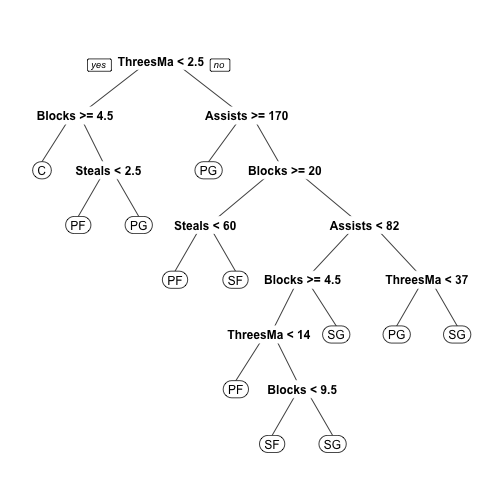

### Classification And Regression Tree (CART)

- 常見的Classification And Regression Tree (CART)
- 使用前須先安裝`rpart` packages

```r
install.packages("rpart")
```

### CART

```r
library(rpart)
DT<-rpart(Position~
            Blocks+ThreesMade+Assists+Steals,
          data=NBA1516)
DT
```

```
n=475 (1 observation deleted due to missingness)

node), split, n, loss, yval, (yprob)
      * denotes terminal node

  1) root 475 364 PF (0.15 0.23 0.21 0.18 0.23)
    2) ThreesMade< 2.5 132  74 C (0.44 0.35 0.098 0.053 0.061)
      4) Blocks>=4.5 89  37 C (0.58 0.38 0.011 0.011 0.011) *
      5) Blocks< 4.5 43  31 PF (0.14 0.28 0.28 0.14 0.16)
       10) Steals< 2.5 29  19 PF (0.17 0.34 0.14 0.21 0.14) *
       11) Steals>=2.5 14   6 PG (0.071 0.14 0.57 0 0.21) *
    3) ThreesMade>=2.5 343 242 SG (0.035 0.19 0.25 0.23 0.29)
      6) Assists>=170.5 96  39 PG (0.031 0.052 0.59 0.15 0.18) *
      7) Assists< 170.5 247 163 SG (0.036 0.24 0.12 0.26 0.34)
       14) Blocks>=20.5 80  42 PF (0.062 0.48 0 0.26 0.2)
         28) Steals< 59.5 58  21 PF (0.069 0.64 0 0.14 0.16) *
         29) Steals>=59.5 22   9 SF (0.045 0.045 0 0.59 0.32) *
       15) Blocks< 20.5 167  99 SG (0.024 0.13 0.17 0.26 0.41)
         30) Assists< 81.5 110  68 SG (0.027 0.18 0.091 0.32 0.38)
           60) Blocks>=4.5 63  39 SF (0.032 0.29 0.016 0.38 0.29)
            120) ThreesMade< 13.5 19   9 PF (0.11 0.53 0 0.26 0.11) *
            121) ThreesMade>=13.5 44  25 SF (0 0.18 0.023 0.43 0.36)
              242) Blocks< 9.5 17   7 SF (0 0.18 0.059 0.59 0.18) *
              243) Blocks>=9.5 27  14 SG (0 0.19 0 0.33 0.48) *
           61) Blocks< 4.5 47  23 SG (0.021 0.043 0.19 0.23 0.51) *
         31) Assists>=81.5 57  31 SG (0.018 0.035 0.33 0.16 0.46)
           62) ThreesMade< 37 17   5 PG (0 0.12 0.71 0.059 0.12) *
           63) ThreesMade>=37 40  16 SG (0.025 0 0.17 0.2 0.6) *
```

### CART

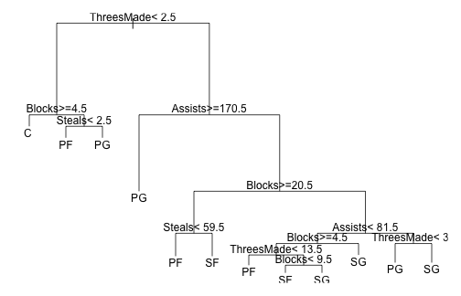

```r
par(mfrow=c(1,1), mar = rep(1,4)) #下,左,上,右
plot(DT)
text(DT, use.n=F, all=F, cex=1)
```

### 決策樹圖

改用`rpart.plot` package 裡面的`prp()`

```r
#第一次使用前須先安裝
install.packages("rpart.plot")
```

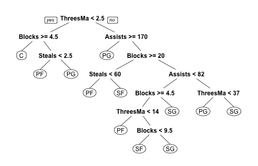

```r
library(rpart.plot)
prp(DT)
```

### 決策樹 節點

決策樹演算法決定`節點`的方式如下：

- Gini impurity
- Information gain
- Variance reduction

細節可參考[維基百科](https://en.wikipedia.org/wiki/Decision_tree_learning)

### 決策樹 練習

- 用[PimaIndiansDiabetes](https://archive.ics.uci.edu/ml/datasets/Pima+Indians+Diabetes)資料
  - install.packages(“mlbench”)
  - library(mlbench)
  - data(PimaIndiansDiabetes)
- 使用所有欄位預測diabetes
  - diabetes~.
- 使用rpart.plot套件畫出決策樹
  - prp()

### 模型驗證

- 在完成模型訓練後，為了驗證模型訓練的好不好，需要用一組**獨立**的測試資料，來做模型的驗證
- 在訓練模型前，必須特別留意是否有保留一份**獨立的資料**，並確保在訓練模型時都不用到此獨立資料集。

因此，資料集可分為以下兩種：

- **訓練組** Training set, Development set: 讓演算法`學`到`知識`
- **測試組** Test set, Validation set: 驗證`學`的怎麼樣

### 模型驗證

- Training set和Test set通常會比例分配
  - 如2/3的資料設為`Training set`
  - 剩下的1/3做驗證`Test set`
- 以下圖的監督式學習流程圖為例，可以注意到綠色箭頭的資料集在訓練過程中從未被使用。

[figure not shown]

### 模型驗證

- 以Training set來`選看起來最好的模型`
- 用Test set來`驗證模型是不是真的很好`
- 想像…..訓練出來題庫答得好的學生，寫到新題目不一定會寫！？
- 訓練模型時，只能看Training set，用Training set來選一個最好的模型
- 訓練模型時，不能偷看Test set，才是真正的驗證

### Regression 迴歸驗證

以NBA資料為例，首先先將資料讀入

```r
#讀入SportsAnalytics package
if (!require('SportsAnalytics')){
    install.packages("SportsAnalytics")
    library(SportsAnalytics)
}
#擷取2015-2016年球季球員資料
NBA1516<-fetch_NBAPlayerStatistics("15-16")
#只保留完整的資料
NBA1516<-NBA1516[complete.cases(NBA1516),]
```

### Regression 迴歸驗證：資料分組

為分出訓練組與測試組，需使用隨機抽樣的方式

```r
sample(1:10,3) # 從1到10，隨機取三個數字
```

```
[1] 3 4 7
```

```r
sample(1:nrow(NBA1516),nrow(NBA1516)/3) #從第一列到最後一列，隨機取1/3列數
```

```
  [1] 108 325 398 353 123 143 144 472 139 326 474 290 303 390 154  71   1
 [18]  51 334 374 201 104 185 445  52 172 296 240 137 219 427 155 248 278
 [35] 384 254 204 475 412 146 118  42 236  64 179 438 348  33 418 451 162
 [52] 428  45 158 423 157  22 141 151 350 383 351 417 113 126 114 239 322
 [69] 262  60 302 426  86 166 465 287 110 187 467 245 441  38 142 233 270
 [86] 337 408 257 345 449 214 196 363 420 285 176  85  84 253 218 344  76
[103] 246 244 241  18 111 235 355 450 294 443 147 156 266  12  90 211 301
[120]  15  53 459 382 435 299 190 329  20 128 471 463 161 361 275 413 440
[137] 422 291 217 394  50 256 120 116 401 309 444 221 360  56 269 247 310
[154] 180 280 437 117 184
```

### Regression 迴歸驗證：資料分組

使用隨機抽樣法，選出1/3的元素位置，把NBA的資料分成Training 和 Test set

```r
NBA1516$Test<-F #新增一個參數紀錄分組
#隨機取1/3當Test set
NBA1516[sample(1:nrow(NBA1516),nrow(NBA1516)/3),]$Test<-T
# Training set : Test set球員數
c(sum(NBA1516$Test==F),sum(NBA1516$Test==T))
```

```
[1] 317 158
```

### Regression 迴歸驗證：模型訓練

並用訓練組的資料（NBA1516$Test==F），訓練一個多變數線性迴歸模型

```r
fit<-glm(TotalPoints~TotalMinutesPlayed+FieldGoalsAttempted+
             Position+ThreesAttempted+FreeThrowsAttempted,
              data =NBA1516[NBA1516$Test==F,])
summary(fit)$coefficients
```

```
                        Estimate  Std. Error   t value      Pr(>|t|)
(Intercept)           7.48869501 6.749514069  1.109516  2.680731e-01
TotalMinutesPlayed    0.01192765 0.006942915  1.717961  8.680885e-02
FieldGoalsAttempted   0.95571510 0.021558158 44.331947 9.994107e-136
PositionPF          -15.57351653 7.427439330 -2.096754  3.683065e-02
PositionPG          -36.43150479 8.040507007 -4.530996  8.408743e-06
PositionSF          -19.43606280 8.308298425 -2.339355  1.995591e-02
PositionSG          -18.99678595 8.295109451 -2.290119  2.269020e-02
ThreesAttempted       0.12977381 0.028024869  4.630666  5.382474e-06
FreeThrowsAttempted   0.73225375 0.035491426 20.631849  5.295642e-60
```

### Regression 迴歸驗證：逐步選擇模型

逐步選擇模型 stepwise 後退學習：一開始先將所有參數加到模型裡，再一個一個拿掉

```r
library(MASS)
##根據AIC，做逐步選擇, 預設倒退學習 direction = "backward"
##trace=FALSE: 不要顯示步驟
finalModel_B<-stepAIC(fit,direction = "backward",trace=FALSE)
summary(finalModel_B)$coefficients
```

```
                        Estimate  Std. Error   t value      Pr(>|t|)
(Intercept)           7.48869501 6.749514069  1.109516  2.680731e-01
TotalMinutesPlayed    0.01192765 0.006942915  1.717961  8.680885e-02
FieldGoalsAttempted   0.95571510 0.021558158 44.331947 9.994107e-136
PositionPF          -15.57351653 7.427439330 -2.096754  3.683065e-02
PositionPG          -36.43150479 8.040507007 -4.530996  8.408743e-06
PositionSF          -19.43606280 8.308298425 -2.339355  1.995591e-02
PositionSG          -18.99678595 8.295109451 -2.290119  2.269020e-02
ThreesAttempted       0.12977381 0.028024869  4.630666  5.382474e-06
FreeThrowsAttempted   0.73225375 0.035491426 20.631849  5.295642e-60
```